# Biostat 203B Homework 3

Due Feb 21 @ 11:59PM

Author

Emma Mo and 906542365

Load necessary libraries (you can add more as needed).

```r
library(arrow)
library(gtsummary)
library(memuse)
library(pryr)
library(R.utils)
library(tidyverse)
```

Display your machine memory.

```r
memuse::Sys.meminfo()
```

```
Totalram:  16.000 GiB
Freeram:    6.600 GiB
```

In this exercise, we use tidyverse (ggplot2, dplyr, etc) to explore the [MIMIC-IV](https://physionet.org/content/mimiciv/3.1/) data introduced in [homework 1](https://ucla-biostat-203b.github.io/2025winter/hw/hw1/hw1.html) and to build a cohort of ICU stays.

## Q1. Visualizing patient trajectory

Visualizing a patient’s encounters in a health care system is a common task in clinical data analysis. In this question, we will visualize a patient’s ADT (admission-discharge-transfer) history and ICU vitals in the MIMIC-IV data.

### Q1.1 ADT history

A patient’s ADT history records the time of admission, discharge, and transfer in the hospital. This figure shows the ADT history of the patient with `subject_id` 10001217 in the MIMIC-IV data. The x-axis is the calendar time, and the y-axis is the type of event (ADT, lab, procedure). The color of the line segment represents the care unit. The size of the line segment represents whether the care unit is an ICU/CCU. The crosses represent lab events, and the shape of the dots represents the type of procedure. The title of the figure shows the patient’s demographic information and the subtitle shows top 3 diagnoses.

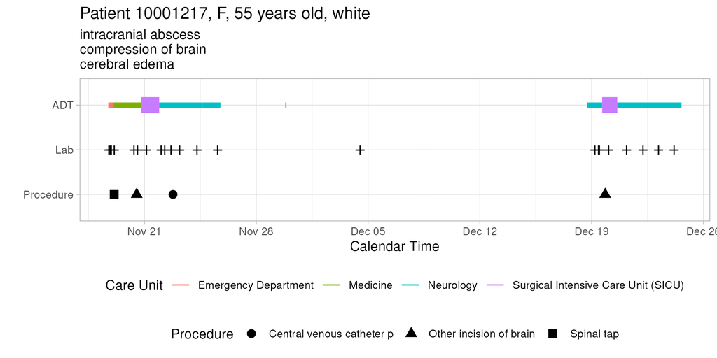

Do a similar visualization for the patient with `subject_id` 10063848 using ggplot.

Hint: We need to pull information from data files `patients.csv.gz`, `admissions.csv.gz`, `transfers.csv.gz`, `labevents.csv.gz`, `procedures_icd.csv.gz`, `diagnoses_icd.csv.gz`, `d_icd_procedures.csv.gz`, and `d_icd_diagnoses.csv.gz`. For the big file `labevents.csv.gz`, use the Parquet format you generated in Homework 2. For reproducibility, make the Parquet folder `labevents_pq` available at the current working directory `hw3`, for example, by a symbolic link. Make your code reproducible.

```r
source_dir <- "../hw2/labevents.parquet"
target_dir <- "labevents_pq"

if (file.exists(target_dir) || dir.exists(target_dir)) {
  unlink(target_dir, recursive = TRUE)
}

file.symlink(from = source_dir, to = target_dir)
```

```
[1] TRUE
```

```r
file.exists(target_dir)
```

```
[1] TRUE
```

```r
parquet_dir <- "labevents_pq/"
labevents <- open_dataset(parquet_dir)
```

```r
hosp_dir <- "~/mimic/hosp"

patients       <- read_csv(file.path(hosp_dir, "patients.csv.gz"))
admissions     <- read_csv(file.path(hosp_dir, "admissions.csv.gz"))
transfers      <- read_csv(file.path(hosp_dir, "transfers.csv.gz"))
procedures     <- read_csv(file.path(hosp_dir, "procedures_icd.csv.gz"))
diagnoses      <- read_csv(file.path(hosp_dir, "diagnoses_icd.csv.gz"))
d_icd_procedures <- read_csv(file.path(hosp_dir, "d_icd_procedures.csv.gz"))
d_icd_diagnoses  <- read_csv(file.path(hosp_dir, "d_icd_diagnoses.csv.gz"))
```

```r
subject_id <- 10063848

# Filter patient info
patient_info <- patients %>%
  filter(subject_id == !!subject_id)

# Filter admissions info
admissions_info <- admissions %>%
  filter(subject_id == !!subject_id)

# Process transfers (ADT) info, converting to Date only
transfers_info <- transfers %>%
  filter(subject_id == !!subject_id) %>%
  mutate(
    event_type = "ADT",
    start_date = as.Date(intime),
    end_date   = as.Date(outtime),
    is_icu     = str_detect(careunit, "ICU|CCU")
  )

# Process lab events, converting charttime to Date
lab_info <- labevents %>%
  filter(subject_id == !!subject_id) %>%
  collect() %>%
  mutate(
    event_type = "Lab",
    start_date = as.Date(charttime)
  )

# Process procedures, converting chartdate to Date
procedures_info <- procedures %>%
  filter(subject_id == !!subject_id) %>%
  left_join(d_icd_procedures, by = "icd_code") %>%
  mutate(
    event_type = "Procedure",
    start_date = as.Date(chartdate)
  )

# Get top 3 diagnoses
diagnoses_info <- diagnoses %>%
  filter(subject_id == !!subject_id) %>%
  left_join(d_icd_diagnoses, by = "icd_code") %>%
  select(subject_id, hadm_id, icd_code, long_title)
top_diagnoses <- diagnoses_info %>%
  slice_head(n = 3) %>%
  pull(long_title)
```

[figure not shown]

```r
# Convert is_icu to a factor (for proper mapping)
transfers_info <- transfers_info %>%
  mutate(is_icu = as.factor(is_icu))

# Create the plot using ggplot2 with Date-based x-axis
ggplot() +
  # ADT segments
  geom_segment(
    data = transfers_info,
    aes(x = start_date, xend = end_date,
        y = event_type, yend = event_type,
        color = careunit, linewidth = is_icu)
  ) +
  scale_linewidth_manual(values = c("FALSE" = 0.5, "TRUE" = 2)) +

  # Lab events as crosses
  geom_point(
    data = lab_info,
    aes(x = start_date, y = event_type),
    shape = 4  # cross shape
  ) +

  # Procedures as points with different shapes
  geom_point(
    data = procedures_info,
    aes(x = start_date, y = event_type, shape = long_title),
    size = 3
  ) +

  labs(
    title = paste0(
      "Patient ", subject_id, ", ",
      patient_info$gender, ", ",
      patient_info$anchor_age, " years old ",
      admissions_info$race
    ),
    subtitle = paste("Top Diagnoses:\n", paste(top_diagnoses, collapse = "\n")),
    x = "Calendar Time",
    y = NULL,
    color = "Care Unit",
    shape = "Procedure",
    linewidth = "ICU/CCU"
  ) +
  theme_minimal() +
  theme(legend.position = "bottom") +
  scale_x_date(date_breaks = "2 weeks", date_labels = "%b %d")
```

### Q1.2 ICU stays

ICU stays are a subset of ADT history. This figure shows the vitals of the patient `10001217` during ICU stays. The x-axis is the calendar time, and the y-axis is the value of the vital. The color of the line represents the type of vital. The facet grid shows the abbreviation of the vital and the stay ID.

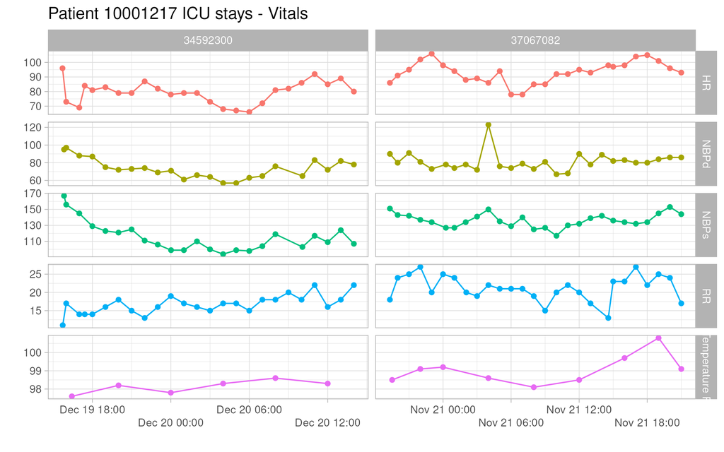

Do a similar visualization for the patient `10063848`.

```r
csv_file <- "~/mimic/icu/chartevents.csv.gz"
parquet_file <- "~/mimic/icu/csv_file"

parquet_data <- open_dataset(parquet_file, format = "parquet")

chartevents_data <- parquet_data %>%
  filter(subject_id %in% c(10063848))
chartevents <- collect(chartevents_data)
```

```r
d_items     <- read_csv("~/mimic/icu/d_items.csv.gz")
```

```r
chartevents_joined <- chartevents %>%
  left_join(d_items, by = "itemid")

subject_of_interest <- 10063848

vitals <- chartevents_joined %>%
  filter(
    subject_id == subject_of_interest,
    label %in% c("Heart Rate",
                 "Non Invasive Blood Pressure systolic",
                 "Non Invasive Blood Pressure diastolic",
                 "Respiratory Rate",
                 "Temperature Fahrenheit")
  ) %>%
  mutate(
    charttime = ymd_hms(charttime)  # parse as POSIXct
  )
```

```r
icustays <- read_csv("~/mimic/icu/icustays.csv.gz") %>%
  filter(subject_id == subject_of_interest) %>%
  mutate(
    intime  = ymd_hms(intime),
    outtime = ymd_hms(outtime)
  )
```

```r
vitals_icu <- vitals %>%
  inner_join(icustays, by = c("subject_id", "stay_id"))
```

```r
vitals_icu <- vitals_icu %>%
  mutate(
    vital_abbr = case_when(
      label == "Heart Rate" ~ "HR",
      label == "Non Invasive Blood Pressure systolic"  ~ "NBPs",
      label == "Non Invasive Blood Pressure diastolic" ~ "NBPd",
      label == "Respiratory Rate" ~ "RR",
      label == "Temperature Fahrenheit" ~ "Temperature Fahrenheit",
      TRUE ~ label
    )
  )
```

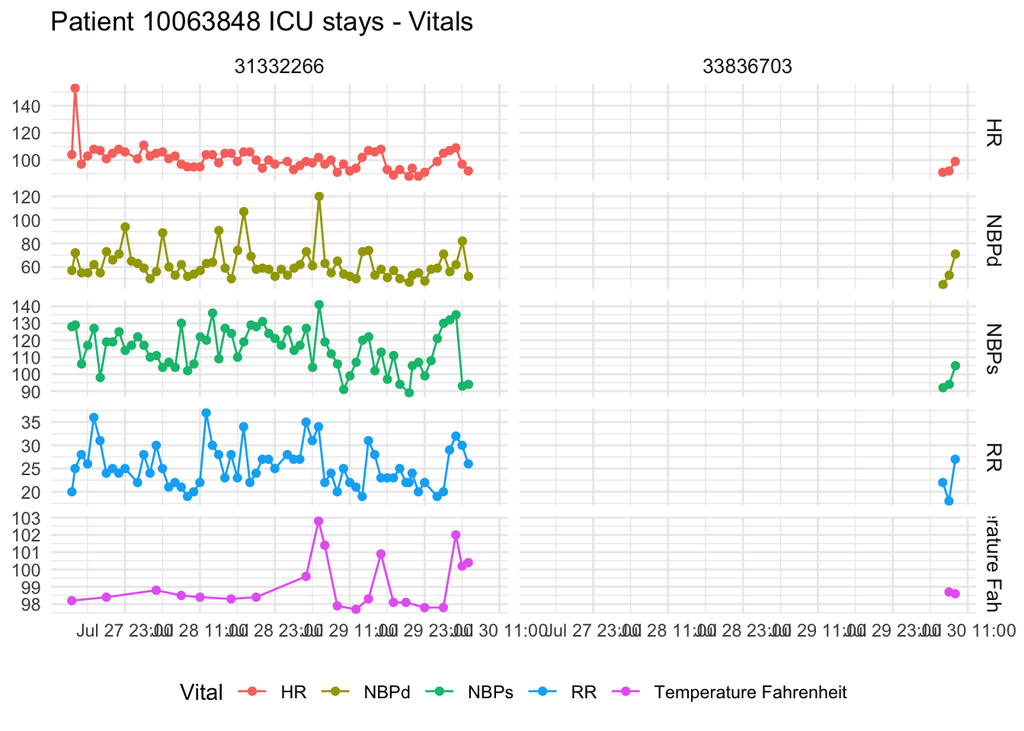

```r
ggplot(vitals_icu, aes(x = charttime, y = valuenum, color = vital_abbr)) +
  geom_line() +
  geom_point() +
  facet_grid(vital_abbr ~ stay_id, scales = "free_y") +
  scale_x_datetime(date_breaks = "12 hours", date_labels = "%b %d %H:%M") +
  labs(
    title = paste("Patient", subject_of_interest, "ICU stays - Vitals"),
    x = NULL,
    y = NULL,  # or "Value"
    color = "Vital"
  ) +
  theme_minimal() +
  theme(
    legend.position = "bottom",
    strip.text = element_text(size = 10)
  )
```

## Q2. ICU stays

`icustays.csv.gz` (https://mimic.mit.edu/docs/iv/modules/icu/icustays/) contains data about Intensive Care Units (ICU) stays. The first 10 lines are

```bash
zcat < ~/mimic/icu/icustays.csv.gz | head
```

```
subject_id,hadm_id,stay_id,first_careunit,last_careunit,intime,outtime,los
10000032,29079034,39553978,Medical Intensive Care Unit (MICU),Medical Intensive Care Unit (MICU),2180-07-23 14:00:00,2180-07-23 23:50:47,0.4102662037037037
10000690,25860671,37081114,Medical Intensive Care Unit (MICU),Medical Intensive Care Unit (MICU),2150-11-02 19:37:00,2150-11-06 17:03:17,3.8932523148148146
10000980,26913865,39765666,Medical Intensive Care Unit (MICU),Medical Intensive Care Unit (MICU),2189-06-27 08:42:00,2189-06-27 20:38:27,0.4975347222222222
10001217,24597018,37067082,Surgical Intensive Care Unit (SICU),Surgical Intensive Care Unit (SICU),2157-11-20 19:18:02,2157-11-21 22:08:00,1.1180324074074075
10001217,27703517,34592300,Surgical Intensive Care Unit (SICU),Surgical Intensive Care Unit (SICU),2157-12-19 15:42:24,2157-12-20 14:27:41,0.948113425925926
10001725,25563031,31205490,Medical/Surgical Intensive Care Unit (MICU/SICU),Medical/Surgical Intensive Care Unit (MICU/SICU),2110-04-11 15:52:22,2110-04-12 23:59:56,1.338587962962963
10001843,26133978,39698942,Medical/Surgical Intensive Care Unit (MICU/SICU),Medical/Surgical Intensive Care Unit (MICU/SICU),2134-12-05 18:50:03,2134-12-06 14:38:26,0.8252662037037037
10001884,26184834,37510196,Medical Intensive Care Unit (MICU),Medical Intensive Care Unit (MICU),2131-01-11 04:20:05,2131-01-20 08:27:30,9.17181712962963
10002013,23581541,39060235,Cardiac Vascular Intensive Care Unit (CVICU),Cardiac Vascular Intensive Care Unit (CVICU),2160-05-18 10:00:53,2160-05-19 17:33:33,1.314351851851852
```

### Q2.1 Ingestion

Import `icustays.csv.gz` as a tibble `icustays_tble`.

```r
icustays_tble <- read_csv("~/mimic/icu/icustays.csv.gz")
```

### Q2.2 Summary and visualization

How many unique `subject_id`? Can a `subject_id` have multiple ICU stays? Summarize the number of ICU stays per `subject_id` by graphs.

```r
num_unique_subjects <- icustays_tble %>%
  summarize(n_unique_subjects = n_distinct(subject_id)) %>%
  pull(n_unique_subjects)
num_unique_subjects
```

```
[1] 65366
```

There are 65366 unique `subject_id`.

```r
subject_stays <- icustays_tble %>%
  group_by(subject_id) %>%
  summarize(n_stays = n(), .groups = "drop")
subject_stays
```

```
# A tibble: 65,366 × 2
   subject_id n_stays
        <dbl>   <int>
 1   10000032       1
 2   10000690       1
 3   10000980       1
 4   10001217       2
 5   10001725       1
 6   10001843       1
 7   10001884       1
 8   10002013       1
 9   10002114       1
10   10002155       3
# ℹ 65,356 more rows
```

```r
sum(subject_stays$n_stays > 1)
```

```
[1] 16242
```

Yes, a `subject_id` can have multiple ICU stays.

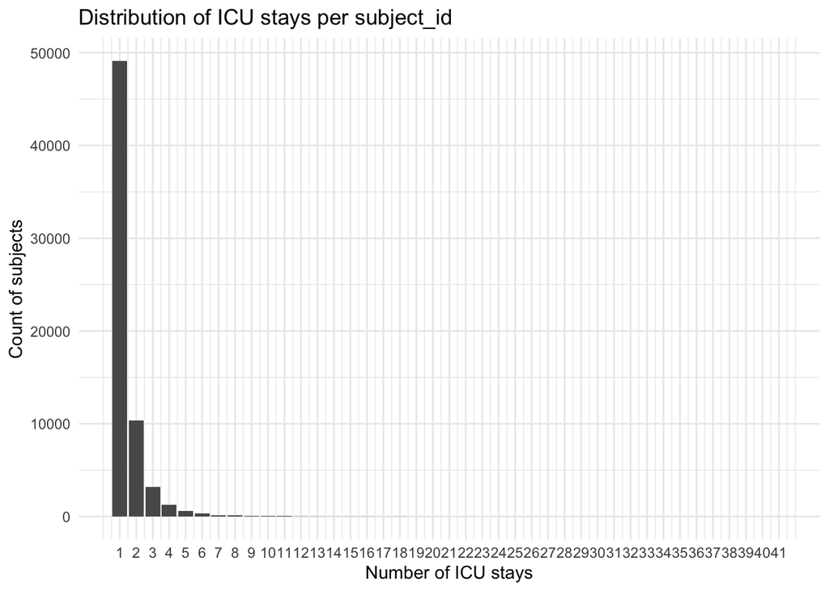

```r
ggplot(subject_stays, aes(x = n_stays)) +
  geom_bar() +
  scale_x_continuous(breaks = 1:max(subject_stays$n_stays)) +
  labs(
    title = "Distribution of ICU stays per subject_id",
    x = "Number of ICU stays",
    y = "Count of subjects"
  ) +
  theme_minimal()
```

## Q3. `admissions` data

Information of the patients admitted into hospital is available in `admissions.csv.gz`. See https://mimic.mit.edu/docs/iv/modules/hosp/admissions/ for details of each field in this file. The first 10 lines are

```bash
zcat < ~/mimic/hosp/admissions.csv.gz | head
```

```
subject_id,hadm_id,admittime,dischtime,deathtime,admission_type,admit_provider_id,admission_location,discharge_location,insurance,language,marital_status,race,edregtime,edouttime,hospital_expire_flag
10000032,22595853,2180-05-06 22:23:00,2180-05-07 17:15:00,,URGENT,P49AFC,TRANSFER FROM HOSPITAL,HOME,Medicaid,English,WIDOWED,WHITE,2180-05-06 19:17:00,2180-05-06 23:30:00,0
10000032,22841357,2180-06-26 18:27:00,2180-06-27 18:49:00,,EW EMER.,P784FA,EMERGENCY ROOM,HOME,Medicaid,English,WIDOWED,WHITE,2180-06-26 15:54:00,2180-06-26 21:31:00,0
10000032,25742920,2180-08-05 23:44:00,2180-08-07 17:50:00,,EW EMER.,P19UTS,EMERGENCY ROOM,HOSPICE,Medicaid,English,WIDOWED,WHITE,2180-08-05 20:58:00,2180-08-06 01:44:00,0
10000032,29079034,2180-07-23 12:35:00,2180-07-25 17:55:00,,EW EMER.,P06OTX,EMERGENCY ROOM,HOME,Medicaid,English,WIDOWED,WHITE,2180-07-23 05:54:00,2180-07-23 14:00:00,0
10000068,25022803,2160-03-03 23:16:00,2160-03-04 06:26:00,,EU OBSERVATION,P39NWO,EMERGENCY ROOM,,,English,SINGLE,WHITE,2160-03-03 21:55:00,2160-03-04 06:26:00,0
10000084,23052089,2160-11-21 01:56:00,2160-11-25 14:52:00,,EW EMER.,P42H7G,WALK-IN/SELF REFERRAL,HOME HEALTH CARE,Medicare,English,MARRIED,WHITE,2160-11-20 20:36:00,2160-11-21 03:20:00,0
10000084,29888819,2160-12-28 05:11:00,2160-12-28 16:07:00,,EU OBSERVATION,P35NE4,PHYSICIAN REFERRAL,,Medicare,English,MARRIED,WHITE,2160-12-27 18:32:00,2160-12-28 16:07:00,0
10000108,27250926,2163-09-27 23:17:00,2163-09-28 09:04:00,,EU OBSERVATION,P40JML,EMERGENCY ROOM,,,English,SINGLE,WHITE,2163-09-27 16:18:00,2163-09-28 09:04:00,0
10000117,22927623,2181-11-15 02:05:00,2181-11-15 14:52:00,,EU OBSERVATION,P47EY8,EMERGENCY ROOM,,Medicaid,English,DIVORCED,WHITE,2181-11-14 21:51:00,2181-11-15 09:57:00,0
```

### Q3.1 Ingestion

Import `admissions.csv.gz` as a tibble `admissions_tble`.

```r
admissions_tble <- read_csv("~/mimic/hosp/admissions.csv.gz")
```

### Q3.2 Summary and visualization

Summarize the following information by graphics and explain any patterns you see.

- number of admissions per patient
- admission hour (anything unusual?)
- admission minute (anything unusual?)
- length of hospital stay (from admission to discharge) (anything unusual?)

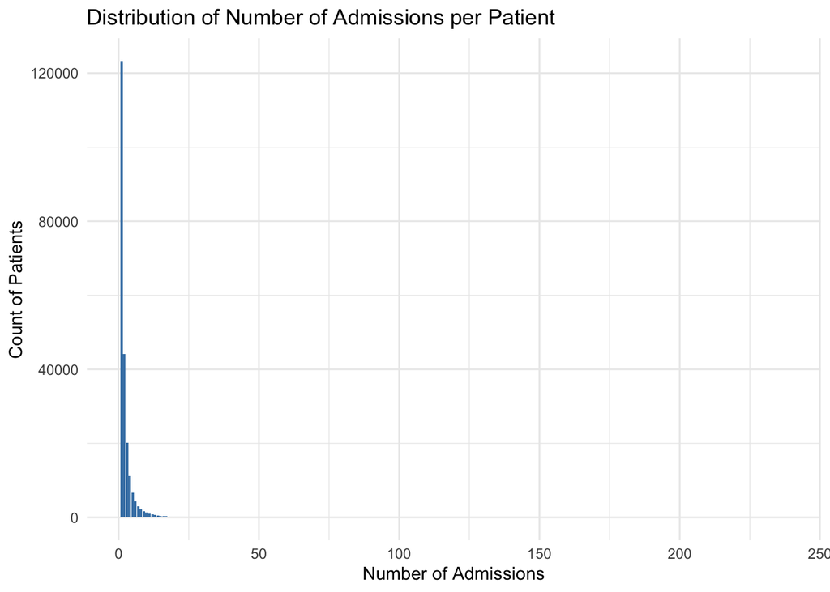

```r
library(tidyverse)
library(lubridate)  # For working with dates/times

adm_per_patient <- admissions_tble %>%
  group_by(subject_id) %>%
  summarize(n_admissions = n(), .groups = "drop")

ggplot(adm_per_patient, aes(x = n_admissions)) +
  geom_bar(fill = "steelblue") +
  labs(
    title = "Distribution of Number of Admissions per Patient",
    x = "Number of Admissions",
    y = "Count of Patients"
  ) +
  theme_minimal()
```

- Many patients typically have only 1 admission (common in hospital databases).
- A long, thin tail extending out to higher numbers of admissions, meaning fewer patients have many admissions.

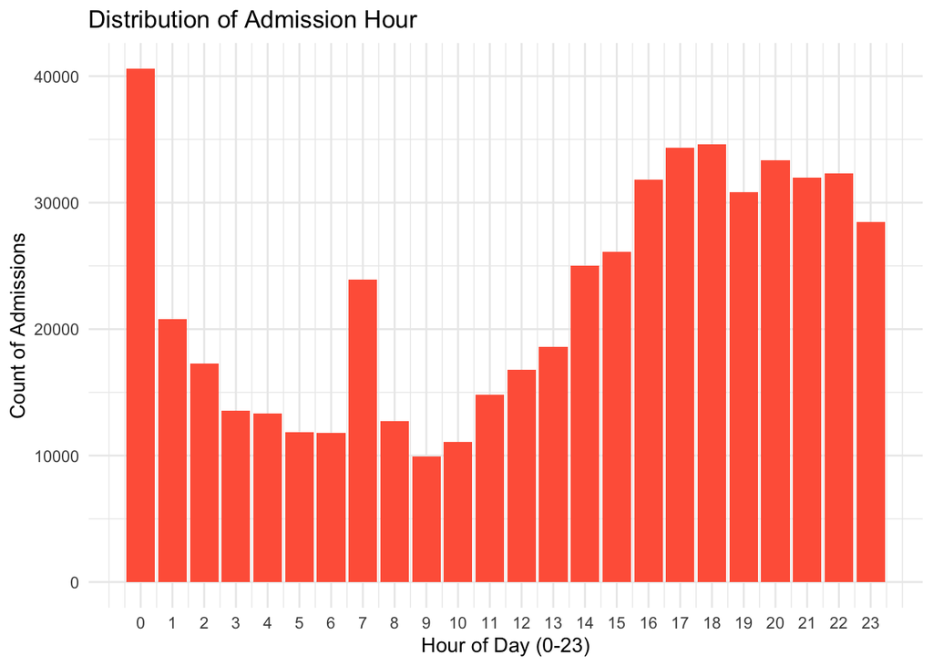

```r
admissions_tble <- admissions_tble %>%
  mutate(admission_hour = hour(admittime))

ggplot(admissions_tble, aes(x = admission_hour)) +
  geom_bar(fill = "tomato") +
  scale_x_continuous(breaks = 0:23) +
  labs(
    title = "Distribution of Admission Hour",
    x = "Hour of Day (0-23)",
    y = "Count of Admissions"
  ) +
  theme_minimal()
```

- A very high bar at hour = 0 (midnight).
- Fewer admissions during the early morning hours (1–9 AM), with another spike at 7 AM.
- A gradual rise and plateau from 10 AM through evening hours.

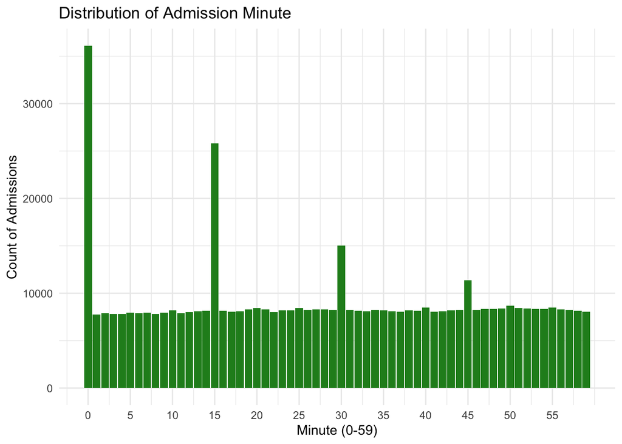

```r
# 1. Extract the minute of admission
admissions_tble <- admissions_tble %>%
  mutate(admission_minute = minute(admittime))

# 2. Plot the distribution of admission_minute
ggplot(admissions_tble, aes(x = admission_minute)) +
  geom_bar(fill = "forestgreen") +
  scale_x_continuous(breaks = seq(0, 59, by = 5)) +
  labs(
    title = "Distribution of Admission Minute",
    x = "Minute (0-59)",
    y = "Count of Admissions"
  ) +
  theme_minimal()
```

Every 15 minutes there is a spike. This is likely due to rounding of the admission time to the nearest 15 minutes.

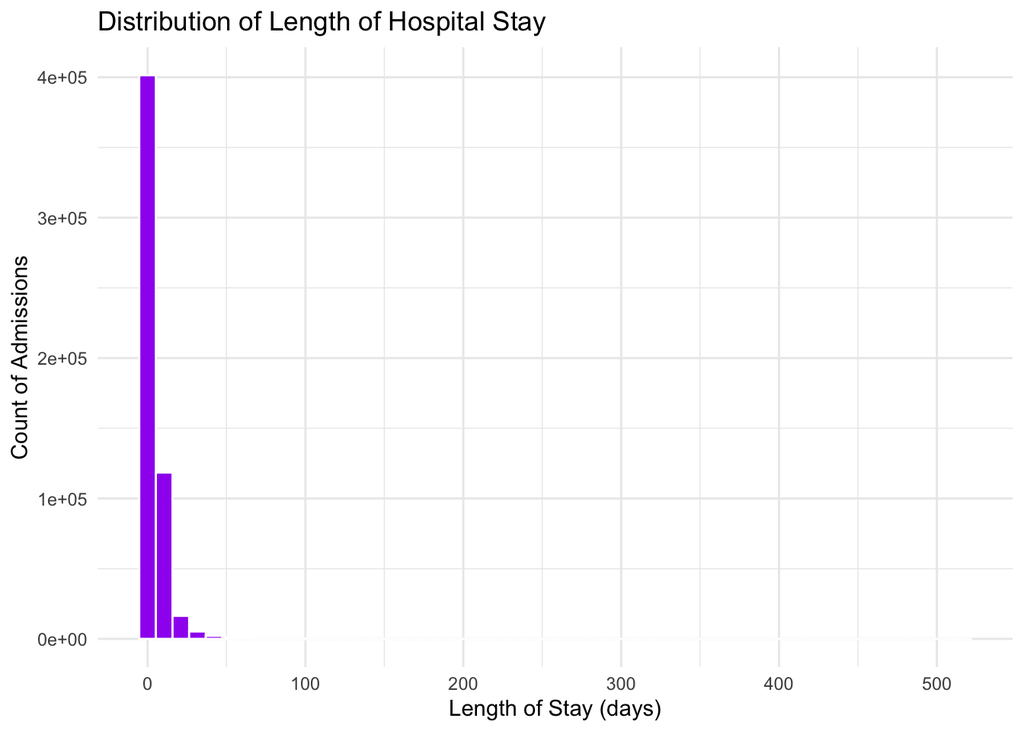

```r
admissions_tble <- admissions_tble %>%
  mutate(
    length_of_stay_days = as.numeric(difftime(dischtime, admittime, units = "days"))
  )

ggplot(admissions_tble, aes(x = length_of_stay_days)) +
  geom_histogram(bins = 50, fill = "purple", color = "white") +
  labs(
    title = "Distribution of Length of Hospital Stay",
    x = "Length of Stay (days)",
    y = "Count of Admissions"
  ) +
  theme_minimal()
```

- A large number of very short stays (near 0–2 days).
- The distribution tapers off quickly but extends to very long stays (hundreds of days).
- A classic right-skewed distribution: many short stays, fewer very long ones.

## Q4. `patients` data

Patient information is available in `patients.csv.gz`. See https://mimic.mit.edu/docs/iv/modules/hosp/patients/ for details of each field in this file. The first 10 lines are

```bash
zcat < ~/mimic/hosp/patients.csv.gz | head
```

```
subject_id,gender,anchor_age,anchor_year,anchor_year_group,dod
10000032,F,52,2180,2014 - 2016,2180-09-09
10000048,F,23,2126,2008 - 2010,
10000058,F,33,2168,2020 - 2022,
10000068,F,19,2160,2008 - 2010,
10000084,M,72,2160,2017 - 2019,2161-02-13
10000102,F,27,2136,2008 - 2010,
10000108,M,25,2163,2014 - 2016,
10000115,M,24,2154,2017 - 2019,
10000117,F,48,2174,2008 - 2010,
```

### Q4.1 Ingestion

Import `patients.csv.gz` (https://mimic.mit.edu/docs/iv/modules/hosp/patients/) as a tibble `patients_tble`.

```r
patients_tble <- read_csv("~/mimic/hosp/patients.csv.gz")
```

### Q4.2 Summary and visualization

Summarize variables `gender` and `anchor_age` by graphics, and explain any patterns you see.

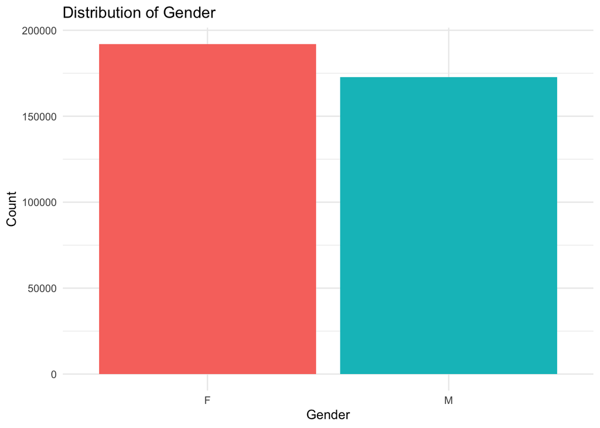

```r
library(tidyverse)

gender_count <- patients_tble %>%
  group_by(gender) %>%
  summarize(count = n(), .groups = "drop")

ggplot(gender_count, aes(x = gender, y = count, fill = gender)) +
  geom_bar(stat = "identity") +
  labs(
    title = "Distribution of Gender",
    x = "Gender",
    y = "Count"
  ) +
  theme_minimal() +
  theme(legend.position = "none")
```

Female is slightly more than male.

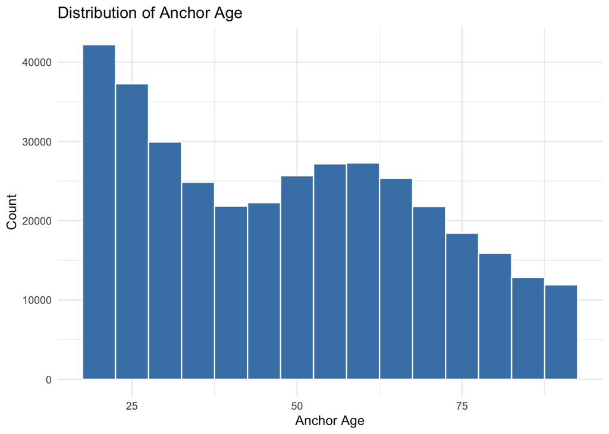

```r
ggplot(patients_tble, aes(x = anchor_age)) +
  geom_histogram(binwidth = 5, fill = "steelblue", color = "white") +
  labs(
    title = "Distribution of Anchor Age",
    x = "Anchor Age",
    y = "Count"
  ) +
  theme_minimal()
```

## Q5. Lab results

`labevents.csv.gz` (https://mimic.mit.edu/docs/iv/modules/hosp/labevents/) contains all laboratory measurements for patients. The first 10 lines are

```bash
zcat < ~/mimic/hosp/labevents.csv.gz | head
```

```
labevent_id,subject_id,hadm_id,specimen_id,itemid,order_provider_id,charttime,storetime,value,valuenum,valueuom,ref_range_lower,ref_range_upper,flag,priority,comments
1,10000032,,2704548,50931,P69FQC,2180-03-23 11:51:00,2180-03-23 15:56:00,___,95,mg/dL,70,100,,ROUTINE,"IF FASTING, 70-100 NORMAL, >125 PROVISIONAL DIABETES."
2,10000032,,36092842,51071,P69FQC,2180-03-23 11:51:00,2180-03-23 16:00:00,NEG,,,,,,ROUTINE,
3,10000032,,36092842,51074,P69FQC,2180-03-23 11:51:00,2180-03-23 16:00:00,NEG,,,,,,ROUTINE,
4,10000032,,36092842,51075,P69FQC,2180-03-23 11:51:00,2180-03-23 16:00:00,NEG,,,,,,ROUTINE,"BENZODIAZEPINE IMMUNOASSAY SCREEN DOES NOT DETECT SOME DRUGS,;INCLUDING LORAZEPAM, CLONAZEPAM, AND FLUNITRAZEPAM."
5,10000032,,36092842,51079,P69FQC,2180-03-23 11:51:00,2180-03-23 16:00:00,NEG,,,,,,ROUTINE,
6,10000032,,36092842,51087,P69FQC,2180-03-23 11:51:00,,,,,,,,ROUTINE,RANDOM.
7,10000032,,36092842,51089,P69FQC,2180-03-23 11:51:00,2180-03-23 16:15:00,,,,,,,ROUTINE,PRESUMPTIVELY POSITIVE.
8,10000032,,36092842,51090,P69FQC,2180-03-23 11:51:00,2180-03-23 16:00:00,NEG,,,,,,ROUTINE,METHADONE ASSAY DETECTS ONLY METHADONE (NOT OTHER OPIATES/OPIOIDS).
9,10000032,,36092842,51092,P69FQC,2180-03-23 11:51:00,2180-03-23 16:00:00,NEG,,,,,,ROUTINE,"OPIATE IMMUNOASSAY SCREEN DOES NOT DETECT SYNTHETIC OPIOIDS;SUCH AS METHADONE, OXYCODONE, FENTANYL, BUPRENORPHINE, TRAMADOL,;NALOXONE, MEPERIDINE.  SEE ONLINE LAB MANUAL FOR DETAILS."
```

`d_labitems.csv.gz` (https://mimic.mit.edu/docs/iv/modules/hosp/d_labitems/) is the dictionary of lab measurements.

```bash
zcat < ~/mimic/hosp/d_labitems.csv.gz | head
```

```
itemid,label,fluid,category
50801,Alveolar-arterial Gradient,Blood,Blood Gas
50802,Base Excess,Blood,Blood Gas
50803,"Calculated Bicarbonate, Whole Blood",Blood,Blood Gas
50804,Calculated Total CO2,Blood,Blood Gas
50805,Carboxyhemoglobin,Blood,Blood Gas
50806,"Chloride, Whole Blood",Blood,Blood Gas
50808,Free Calcium,Blood,Blood Gas
50809,Glucose,Blood,Blood Gas
50810,"Hematocrit, Calculated",Blood,Blood Gas
```

We are interested in the lab measurements of creatinine (50912), potassium (50971), sodium (50983), chloride (50902), bicarbonate (50882), hematocrit (51221), white blood cell count (51301), and glucose (50931). Retrieve a subset of `labevents.csv.gz` that only containing these items for the patients in `icustays_tble`. Further restrict to the last available measurement (by `storetime`) before the ICU stay. The final `labevents_tble` should have one row per ICU stay and columns for each lab measurement.

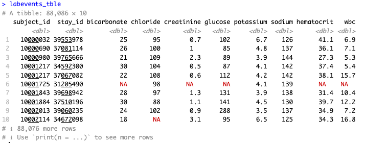

Hint: Use the Parquet format you generated in Homework 2. For reproducibility, make `labevents_pq` folder available at the current working directory `hw3`, for example, by a symbolic link.

```r
library(DBI)
library(duckdb)
library(tidyverse)

con <- dbConnect(duckdb(), dbdir = "mimic.duckdb", read_only = FALSE)

dbExecute(con, "
  CREATE OR REPLACE TABLE labevents AS
  SELECT * FROM parquet_scan('labevents_pq/*.parquet')
")
```

```
[1] 158374764
```

```r
copy_to(con, icustays_tble, "icustays", overwrite = TRUE)
```

```r
dbExecute(con, "
  CREATE OR REPLACE TEMP TABLE labevents_filtered AS
  SELECT subject_id, itemid, storetime, valuenum
  FROM labevents
  WHERE itemid IN (50912, 50971, 50983, 50902, 50882, 51221, 51301, 50931)
")
```

```
[1] 32679896
```

```r
# join icustays, and only keep storetime < intime
dbExecute(con, "
  CREATE OR REPLACE TEMP TABLE labevents_icu AS
  SELECT lf.subject_id,
         i.stay_id,
         lf.itemid,
         lf.storetime,
         lf.valuenum,
         i.intime
  FROM labevents_filtered lf
  JOIN icustays i
    ON lf.subject_id = i.subject_id
  WHERE lf.storetime < i.intime
")
```

```
[1] 20122551
```

```r
# group subject_id, stay_id, itemid, and keep the max storetime
dbExecute(con, "
  CREATE OR REPLACE TEMP TABLE labevents_last AS
  WITH ranked AS (
    SELECT subject_id,
           stay_id,
           itemid,
           valuenum,
           storetime,
           ROW_NUMBER() OVER (
             PARTITION BY subject_id, stay_id, itemid
             ORDER BY storetime DESC
           ) AS rn
    FROM labevents_icu
  )
  SELECT subject_id, stay_id, itemid, valuenum
  FROM ranked
  WHERE rn = 1
")
```

```
[1] 677237
```

```r
labevents_last_df <- dbGetQuery(con, "SELECT * FROM labevents_last")

labevents_wide <- labevents_last_df %>%
  pivot_wider(
    id_cols = c("subject_id", "stay_id"),
    names_from = "itemid",
    values_from = "valuenum"
  ) %>%
  rename(
    creatinine  = `50912`,
    potassium   = `50971`,
    sodium      = `50983`,
    chloride    = `50902`,
    bicarbonate = `50882`,
    hematocrit  = `51221`,
    wbc         = `51301`,
    glucose     = `50931`
  )

labevents_tble <- icustays_tble %>%
  left_join(labevents_wide, by = c("subject_id", "stay_id")) %>%
  arrange(subject_id, stay_id)  # order by subject_id, stay_id
```

```r
labevents_tble_minimal <- labevents_tble %>%
  select(
    subject_id,
    stay_id,
    bicarbonate,
    chloride,
    creatinine,
    glucose,
    potassium,
    sodium,
    hematocrit,
    wbc
  )

print(labevents_tble_minimal)
```

```
# A tibble: 94,458 × 10
   subject_id  stay_id bicarbonate chloride creatinine glucose potassium sodium
        <dbl>    <dbl>       <dbl>    <dbl>      <dbl>   <dbl>     <dbl>  <dbl>
 1   10000032 39553978          25       95        0.7     102       6.7    126
 2   10000690 37081114          26      100        1        85       4.8    137
 3   10000980 39765666          21      109        2.3      89       3.9    144
 4   10001217 34592300          30      104        0.5      87       4.1    142
 5   10001217 37067082          22      108        0.6     112       4.2    142
 6   10001725 31205490          NA       98       NA        NA       4.1    139
 7   10001843 39698942          28       97        1.3     131       3.9    138
 8   10001884 37510196          30       88        1.1     141       4.5    130
 9   10002013 39060235          24      102        0.9     288       3.5    137
10   10002114 34672098          18       NA        3.1      95       6.5    125
# ℹ 94,448 more rows
# ℹ 2 more variables: hematocrit <dbl>, wbc <dbl>
```

## Q6. Vitals from charted events

`chartevents.csv.gz` (https://mimic.mit.edu/docs/iv/modules/icu/chartevents/) contains all the charted data available for a patient. During their ICU stay, the primary repository of a patient’s information is their electronic chart. The `itemid` variable indicates a single measurement type in the database. The `value` variable is the value measured for `itemid`. The first 10 lines of `chartevents.csv.gz` are

```bash
zcat < ~/mimic/icu/chartevents.csv.gz | head
```

```
subject_id,hadm_id,stay_id,caregiver_id,charttime,storetime,itemid,value,valuenum,valueuom,warning
10000032,29079034,39553978,18704,2180-07-23 12:36:00,2180-07-23 14:45:00,226512,39.4,39.4,kg,0
10000032,29079034,39553978,18704,2180-07-23 12:36:00,2180-07-23 14:45:00,226707,60,60,Inch,0
10000032,29079034,39553978,18704,2180-07-23 12:36:00,2180-07-23 14:45:00,226730,152,152,cm,0
10000032,29079034,39553978,18704,2180-07-23 14:00:00,2180-07-23 14:18:00,220048,SR (Sinus Rhythm),,,0
10000032,29079034,39553978,18704,2180-07-23 14:00:00,2180-07-23 14:18:00,224642,Oral,,,0
10000032,29079034,39553978,18704,2180-07-23 14:00:00,2180-07-23 14:18:00,224650,None,,,0
10000032,29079034,39553978,18704,2180-07-23 14:00:00,2180-07-23 14:20:00,223761,98.7,98.7,°F,0
10000032,29079034,39553978,18704,2180-07-23 14:11:00,2180-07-23 14:17:00,220179,84,84,mmHg,0
10000032,29079034,39553978,18704,2180-07-23 14:11:00,2180-07-23 14:17:00,220180,48,48,mmHg,0
```

`d_items.csv.gz` (https://mimic.mit.edu/docs/iv/modules/icu/d_items/) is the dictionary for the `itemid` in `chartevents.csv.gz`.

```bash
zcat < ~/mimic/icu/d_items.csv.gz | head
```

```
itemid,label,abbreviation,linksto,category,unitname,param_type,lownormalvalue,highnormalvalue
220001,Problem List,Problem List,chartevents,General,,Text,,
220003,ICU Admission date,ICU Admission date,datetimeevents,ADT,,Date and time,,
220045,Heart Rate,HR,chartevents,Routine Vital Signs,bpm,Numeric,,
220046,Heart rate Alarm - High,HR Alarm - High,chartevents,Alarms,bpm,Numeric,,
220047,Heart Rate Alarm - Low,HR Alarm - Low,chartevents,Alarms,bpm,Numeric,,
220048,Heart Rhythm,Heart Rhythm,chartevents,Routine Vital Signs,,Text,,
220050,Arterial Blood Pressure systolic,ABPs,chartevents,Routine Vital Signs,mmHg,Numeric,90,140
220051,Arterial Blood Pressure diastolic,ABPd,chartevents,Routine Vital Signs,mmHg,Numeric,60,90
220052,Arterial Blood Pressure mean,ABPm,chartevents,Routine Vital Signs,mmHg,Numeric,,
```

We are interested in the vitals for ICU patients: heart rate (220045), systolic non-invasive blood pressure (220179), diastolic non-invasive blood pressure (220180), body temperature in Fahrenheit (223761), and respiratory rate (220210). Retrieve a subset of `chartevents.csv.gz` only containing these items for the patients in `icustays_tble`. Further restrict to the first vital measurement within the ICU stay. The final `chartevents_tble` should have one row per ICU stay and columns for each vital measurement.

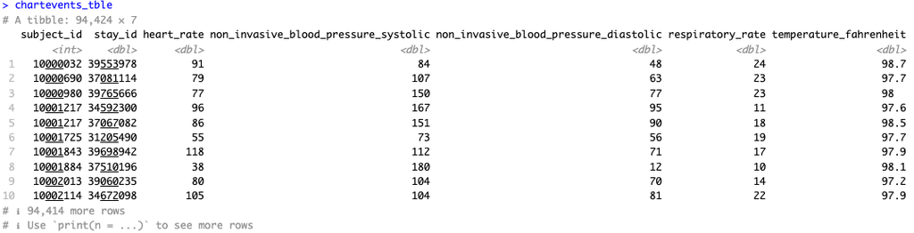

Hint: Use the Parquet format you generated in Homework 2. For reproducibility, make `chartevents_pq` folder available at the current working directory, for example, by a symbolic link.

**First generate chartevents_pq using Parquet**

```r
library(arrow)
library(dplyr)

# Path to your compressed CSV
chartevents_csv <- "~/mimic/icu/chartevents.csv.gz"
# A folder (not a single file) that will contain Parquet data
chartevents_parquet <- "chartevents_pq"
dataset <- open_dataset(chartevents_csv, format = "csv")
write_dataset(dataset, chartevents_parquet, format = "parquet")
```

**Then use the Parquet data to generate the final table**

```r
library(DBI)
library(duckdb)
library(tidyverse)

con <- dbConnect(duckdb(), dbdir = "mimic.duckdb", read_only = FALSE)

dbExecute(con, "
  CREATE OR REPLACE TABLE chartevents AS
  SELECT * FROM parquet_scan('chartevents_pq/*.parquet')
")
```

```
[1] 432997491
```

```r
copy_to(con, icustays_tble, "icustays", overwrite = TRUE)
```

```r
dbExecute(con, "
  CREATE OR REPLACE TEMP TABLE chartevents_filtered AS
  SELECT subject_id, itemid, storetime, valuenum
  FROM chartevents
  WHERE itemid IN (220045, 220179, 220180, 223761, 220210)
")
```

```
[1] 30200193
```

```r
dbExecute(con, "
  CREATE OR REPLACE TEMP TABLE chartevents_icu AS
  SELECT cf.subject_id,
         i.stay_id,
         cf.itemid,
         cf.storetime,
         cf.valuenum,
         i.intime
  FROM chartevents_filtered cf
  JOIN icustays i
    ON cf.subject_id = i.subject_id
  WHERE cf.storetime >= i.intime
")
```

```
[1] 53878236
```

```r
dbExecute(con, "
  CREATE OR REPLACE TEMP TABLE chartevents_first AS
  WITH ranked AS (
    SELECT subject_id,
           stay_id,
           itemid,
           valuenum,
           storetime,
           ROW_NUMBER() OVER (
             PARTITION BY subject_id, stay_id, itemid
             ORDER BY storetime ASC
           ) AS rn
    FROM chartevents_icu
  )
  SELECT subject_id, stay_id, itemid, valuenum
  FROM ranked
  WHERE rn = 1
")
```

```
[1] 468867
```

```r
chartevents_first_df <- dbGetQuery(con, "SELECT * FROM chartevents_first")

chartevents_wide <- chartevents_first_df %>%
  pivot_wider(
    id_cols = c("subject_id", "stay_id"),
    names_from = "itemid",
    values_from = "valuenum"
  ) %>%
  rename(
    heart_rate                        = `220045`,
    non_invasive_blood_pressure_systolic  = `220179`,
    non_invasive_blood_pressure_diastolic = `220180`,
    temperature_fahrenheit           = `223761`,
    respiratory_rate                 = `220210`
  )

chartevents_tble <- icustays_tble %>%
  left_join(chartevents_wide, by = c("subject_id", "stay_id")) %>%
  arrange(subject_id, stay_id)
```

```r
chartevents_tble_minimal <- chartevents_tble %>%
  select(
    subject_id,
    stay_id,
    heart_rate,
    non_invasive_blood_pressure_systolic,
    non_invasive_blood_pressure_diastolic,
    temperature_fahrenheit,
    respiratory_rate
  )

print(chartevents_tble_minimal)
```

```
# A tibble: 94,458 × 7
   subject_id  stay_id heart_rate non_invasive_blood_pr…¹ non_invasive_blood_p…²
        <dbl>    <dbl>      <dbl>                   <dbl>                  <dbl>
 1   10000032 39553978         91                      84                     48
 2   10000690 37081114         79                     107                     63
 3   10000980 39765666         77                     150                     77
 4   10001217 34592300         96                     167                     95
 5   10001217 37067082         86                     151                     90
 6   10001725 31205490         86                      73                     56
 7   10001843 39698942        118                     112                     71
 8   10001884 37510196         38                     180                     12
 9   10002013 39060235         80                     104                     70
10   10002114 34672098        111                     112                     80
# ℹ 94,448 more rows
# ℹ abbreviated names: ¹non_invasive_blood_pressure_systolic,
#   ²non_invasive_blood_pressure_diastolic
# ℹ 2 more variables: temperature_fahrenheit <dbl>, respiratory_rate <dbl>
```

```r
rm(chartevents_first_df, chartevents_wide)
dbDisconnect(con)
```

## Q7. Putting things together

Let us create a tibble `mimic_icu_cohort` for all ICU stays, where rows are all ICU stays of adults (age at `intime` >= 18) and columns contain at least following variables

- all variables in `icustays_tble`
- all variables in `admissions_tble`
- all variables in `patients_tble`
- the last lab measurements before the ICU stay in `labevents_tble`
- the first vital measurements during the ICU stay in `chartevents_tble`

The final `mimic_icu_cohort` should have one row per ICU stay and columns for each variable.

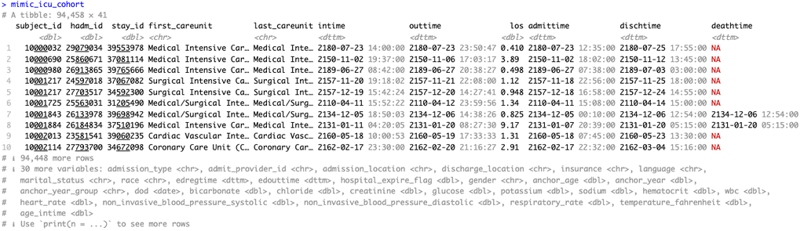

```r
mimic_icu_cohort <- icustays_tble %>%
  # 1) Join ICU stays with admissions
  inner_join(admissions_tble, by = c("subject_id", "hadm_id")) %>%

  # 2) Join with patients
  inner_join(patients_tble, by = "subject_id") %>%

  # 3) Filter to adult ICU stays (example using anchor_age >= 18 in MIMIC-IV)
  filter(anchor_age >= 18) %>%

  # 4) Join the last lab measurements before ICU (one row per ICU stay)
  left_join(labevents_tble, by = c("subject_id", "hadm_id", "stay_id")) %>%

  # 5) Join the first vitals during ICU (also one row per ICU stay)
  left_join(chartevents_tble, by = c("subject_id", "hadm_id", "stay_id"))

mimic_icu_cohort
```

```
# A tibble: 94,458 × 53
   subject_id  hadm_id  stay_id first_careunit.x                 last_careunit.x
        <dbl>    <dbl>    <dbl> <chr>                            <chr>
 1   10000032 29079034 39553978 Medical Intensive Care Unit (MI… Medical Intens…
 2   10000690 25860671 37081114 Medical Intensive Care Unit (MI… Medical Intens…
 3   10000980 26913865 39765666 Medical Intensive Care Unit (MI… Medical Intens…
 4   10001217 24597018 37067082 Surgical Intensive Care Unit (S… Surgical Inten…
 5   10001217 27703517 34592300 Surgical Intensive Care Unit (S… Surgical Inten…
 6   10001725 25563031 31205490 Medical/Surgical Intensive Care… Medical/Surgic…
 7   10001843 26133978 39698942 Medical/Surgical Intensive Care… Medical/Surgic…
 8   10001884 26184834 37510196 Medical Intensive Care Unit (MI… Medical Intens…
 9   10002013 23581541 39060235 Cardiac Vascular Intensive Care… Cardiac Vascul…
10   10002114 27793700 34672098 Coronary Care Unit (CCU)         Coronary Care …
# ℹ 94,448 more rows
# ℹ 48 more variables: intime.x <dttm>, outtime.x <dttm>, los.x <dbl>,
#   admittime <dttm>, dischtime <dttm>, deathtime <dttm>, admission_type <chr>,
#   admit_provider_id <chr>, admission_location <chr>,
#   discharge_location <chr>, insurance <chr>, language <chr>,
#   marital_status <chr>, race <chr>, edregtime <dttm>, edouttime <dttm>,
#   hospital_expire_flag <dbl>, admission_hour <int>, admission_minute <int>, …
```

## Q8. Exploratory data analysis (EDA)

Summarize the following information about the ICU stay cohort `mimic_icu_cohort` using appropriate numerics or graphs:

- Length of ICU stay `los` vs demographic variables (race, insurance, marital_status, gender, age at intime)
- Length of ICU stay `los` vs the last available lab measurements before ICU stay
- Length of ICU stay `los` vs the first vital measurements within the ICU stay
- Length of ICU stay `los` vs first ICU unit